# miR34a asRNA doxorubicin treatment of HCT116 p53 wt and null

Jason T. Serviss

30/01/2017

# Introduction

miR34a is a known downstream target of p53 and has been previously shown to exhibit increased expression with cellular apoptotic signaling. We hypothesized that miR34a asRNA may be regulated in a similar fashion whereby transcription is stimulated by activation of p53. To test this we treated p53+/+ and p53-/- HCT116 cells with increasing concentrations of the DNA damaging agent doxorubicin and monitored miR34a asRNA expression.

# Methods

HCT116 cells were cultured in DMEM high modified (Hyclone, GE healthcare) supplemented with supplemented with 2mM L-glutamine, 50ug/ml Penicillin-Streptomycin and 10% Fetal Calf Serum.  
25 x 10^5 HCT116 cells were plated in 6 well plates. 24 hours later media was exchanged and doxorubicin was added to a final concentration of 100, 200 or 500 ng/ml. Cells were harvested for RNA extraction 24 hours later using trypsin. RNA was extracted using Nucleospin RNA kit (Machery-Nagel Ref. 740955) according to manufacturer‟s protocol and DNase treated using Ambion Turbo DNA-free according to manufacturer‟s protocol (Life Technologies Ref. AM1907). cDNA was synthesized using ~500 ng RNA with M-MLV (Life Technologies Ref 28025013) and a mixture of oligo(dT) with nanomers in accordance with the manufacturer’s protocol. qPCR quantification was carried out using the PowerUp SYBR Green Master Mix (Thermo Fisher Scientific, Ref. A25777) on the CFX96 Touch Real-Time PCR Detection System: 50°C for 2 min, 95°C for 2min, and 95°C for 1 sec followed by 60°C for 30 sec repeated for 40 cycles. The following primers were used:

```r
library(printr)
primers <- data.frame(
    name=c(
        "ß-actin Fwd",
        "ß-actin Rev",
        "miR34a HG_F",
        "miR34a HG_R",
        "miR34a_asF1",
        "miR34a_asR1"

    ),
    sequence=c(
        "AGGTCATCACCATTGGCAATGAG",
        "CTTTCGGGATGTCCACGTCA",
        "TCTGCTCCAGTGGCTGATGAGAAA",
        "GTTCACTGGCCTCAAAGTTGGCAT",
        "AGCGGCATCTCCTCCACCTGAAA",
        "TTGCCTCGTGAGTCCAAGGAGAAT"

    )
)
primers
```

| name | sequence |
| --- | --- |
| ß-actin Fwd | AGGTCATCACCATTGGCAATGAG |
| ß-actin Rev | CTTTCGGGATGTCCACGTCA |
| miR34a HG_F | TCTGCTCCAGTGGCTGATGAGAAA |
| miR34a HG_R | GTTCACTGGCCTCAAAGTTGGCAT |
| miR34a_asF1 | AGCGGCATCTCCTCCACCTGAAA |
| miR34a_asR1 | TTGCCTCGTGAGTCCAAGGAGAAT |

# Results

```r
library(reshape2)
library(ggplot2)
library(ggthemes)
library(plyr)
data <- read.table('~/GitHub/miR34aFigures/inst/HCT116p53null/QPCRdata.txt', header=TRUE, sep="\t")
colnames(data)[which(colnames(data) == "Target")] <- "Gene"

goi <- subset(data, Gene %in% c("miR34a AS", "miR34a HG"))
hk <- subset(data, Gene == "Actin")

colnames(goi)[c(6:7)] <- c("Ct1GOI", "Ct2GOI")
colnames(hk)[c(6:7)] <- c("Ct1HK", "Ct2HK")

data <- merge(goi, hk[, colnames(hk) != "Gene"], by = c("Condition", "Treatment", "Biological.Replicate", "Cell.line"))


#ddct
data$meanGOI <- rowMeans(data[, c("Ct1GOI", "Ct2GOI")])
data$meanHK <- rowMeans(data[, c("Ct1HK", "Ct2HK")])
data$dct <- data$meanGOI - data$meanHK
ddct <- ddply(
    data,
    c("Gene", "Condition", "Treatment", "Biological.Replicate"),
    summarize,
    ddct=dct-data[data$Gene == Gene & data$Condition == Condition & data$Treatment == 0 & data$Biological.Replicate == Biological.Replicate, "dct"]
)

data <- merge(data, ddct, by=c("Gene", "Condition", "Treatment", "Biological.Replicate"))
data$fold <- 2^-data$ddct
data$log2fold <- log2(data$fold)

#calculate stats
stats <- ddply(
    data,
    c("Gene", "Condition", "Treatment"),
    summarize,
    n=length(log2fold),
    mean=mean(log2fold),
    pValue=t.test(log2fold, data[data$Gene == Gene & data$Condition == "WT" & data$Treatment == Treatment, "log2fold"])$p.value,
    CI95l=t.test(log2fold)$conf.int[1],
    CI95h=t.test(log2fold)$conf.int[2]
)

data <- merge(data, stats, by = c("Gene", "Condition", "Treatment"))
#data$pValue <- ifelse(data$pValue == 1, NA, data$pValue)

data$pStars <- ifelse(
    data$pValue < 0.05 & data$pValue > 0.0049,
    "\u2605",
    ifelse(
        data$pValue < 0.005 & data$pValue > 0.00049,
        "\u2605\u2605",
        ifelse(
            data$pValue < 0.0005,
            "\u2605\u2605\u2605",
            "n.s."
        )
    )
)

yS <- ddply(data, c("Gene", "Treatment"), summarize, max = max(CI95h))
pBars <- ddply(
    data,
    c("Gene", "Condition", "Treatment"),
    summarize,
    CI95l = unique(CI95l),
    CI95h = unique(CI95h),
    pStars = unique(pStars),
    pValue = unique(pValue)
)
pBars[pBars$Condition == "WT", "pStars"] <- ""
pBars <- merge(pBars, yS, by = c("Gene", "Treatment"))
pBars$x <- dplyr::case_when(
    pBars$Treatment ==   0 ~ 1 + 0.25,
    pBars$Treatment == 100 ~ 2 + 0.25,
    pBars$Treatment == 200 ~ 3 + 0.25,
    pBars$Treatment == 500 ~ 4 + 0.25
)

pBars$xend <- dplyr::case_when(
    pBars$Treatment ==   0 ~ 1 - 0.25,
    pBars$Treatment == 100 ~ 2 - 0.25,
    pBars$Treatment == 200 ~ 3 - 0.25,
    pBars$Treatment == 500 ~ 4 - 0.25
)

#prepare for plotting
data$Treatment <- factor(data$Treatment, levels=c("0", "100", "200", "500"))
pBars$Treatment <- factor(pBars$Treatment, levels=c("0", "100", "200", "500"))
data$Condition <- ifelse(data$Condition == "WT", "p53-wt", "p53-null")
pBars$Condition <- ifelse(pBars$Condition == "WT", "p53-wt", "p53-null")
data$Condition <- factor(data$Condition, levels=c("p53-wt", "p53-null"))
pBars$Condition <- factor(pBars$Condition, levels=c("p53-wt", "p53-null"))

data$Gene <- ifelse(data$Gene == "miR34a AS", "miR34a asRNA", "miR34a HG")
data$Gene <- factor(data$Gene, levels = c("miR34a HG", "miR34a asRNA"))
pBars$Gene <- ifelse(pBars$Gene == "miR34a AS", "miR34a asRNA", "miR34a HG")
pBars$Gene <- factor(pBars$Gene, levels = c("miR34a HG", "miR34a asRNA"))
```

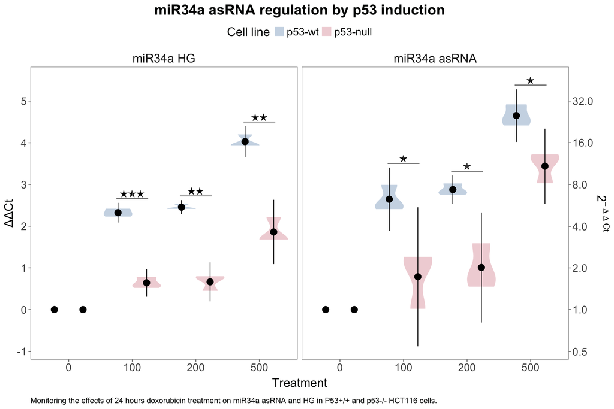

```r
#plot for Rmarkdown
ggplot(data = NULL) +
    geom_violin(
        data = data,
        aes(x = Treatment, y = log2fold, fill = Condition),
        trim = TRUE,
        alpha = 0.3,
        color = NA,
        scale = "width",
        show.legend = TRUE
    ) +
    geom_point(
        data = data,
        aes(x = Treatment, y = mean, group = Condition),
        position = position_dodge(width = 0.9),
        size = 4
    ) +
    facet_grid(. ~ Gene) +
    geom_linerange(
        data = pBars,
        aes(x = Treatment, ymin = CI95l, ymax = CI95h, group = Condition),
        colour = "black",
        position = position_dodge(width = 0.9),
        show.legend = FALSE
    ) +
    geom_label(
        data = pBars,
        aes(x = Treatment, y = max + 0.22, label = pStars),
        label.size = 0,
        label.padding = unit(0.01, "lines"),
        show.legend = FALSE,
        fill = "white",
        size = 5,
        family = "Arial Unicode MS",
        position = position_dodge(width = 0.9)
    ) +
    geom_segment(
        data = pBars,
        aes(x = x, y = max + 0.1, xend = xend, yend = max + 0.1),
        colour="grey43",
        show.legend = FALSE
    ) +
    scale_y_continuous(
        "\u0394\u0394Ct",
        breaks=c(-1,0,1,2,3,4,5),
        sec.axis = sec_axis(
            ~2^.,
            name = expression(2^{- ~ Delta ~ Delta ~ "Ct"}),
            breaks=c(2^-1,2^0,2^1,2^2,2^3,2^4,2^5)
        )
    )+
    labs(
      x="Treatment",
      title="miR34a asRNA regulation by p53 induction",
      caption=
            "Monitoring the effects of 24 hours doxorubicin treatment on miR34a asRNA and HG in P53+/+ and p53-/- HCT116 cells."
    )+
    theme_few()+
    scale_fill_ptol()+
    scale_colour_ptol()+
    #values=c("#014d64", "#6794a7")
    theme(
        plot.title = element_text(
            hjust = 0.5,
            face="bold",
            size=20
        ),
        plot.caption = element_text(
            hjust=0,
            margin=margin(t=15),
            family="Arial Unicode MS"
        ),
        legend.position = "top",
        legend.title=element_text(size=17),
        legend.text=element_text(size=15),
        axis.title=element_text(size=17),
        axis.title.x=element_text(margin=margin(t=10)),
        axis.text=element_text(size=15),
        strip.text.x=element_text(size=17)
    )+
    guides(fill = guide_legend(title = "Cell line", override.aes = list(size=3)))
```

```r
#plot for pdf
p <- ggplot(data = NULL) +
    geom_violin(
        data = data,
        aes(x = Treatment, y = log2fold, fill = Condition),
        trim = TRUE,
        alpha = 0.3,
        color = NA,
        scale = "width",
        show.legend = TRUE
    ) +
    geom_point(
        data = data,
        aes(x = Treatment, y = mean, group = Condition),
        position = position_dodge(width = 0.9),
        size = 0.5
    ) +
    facet_grid(. ~ Gene) +
    geom_linerange(
        data = pBars,
        aes(x = Treatment, ymin = CI95l, ymax = CI95h, group = Condition),
        colour = "black",
        position = position_dodge(width = 0.9),
        show.legend = FALSE,
        lwd = 0.15
    ) +
    geom_label(
        data = pBars,
        aes(x = Treatment, y = max + 0.35, label = pStars),
        label.size = 0,
        label.padding = unit(0.01, "lines"),
        show.legend = FALSE,
        fill = "white",
        size = 1,
        family = "Arial Unicode MS",
        position = position_dodge(width = 0.9)
    ) +
    geom_segment(
        data = pBars,
        aes(x = x, y = max + 0.1, xend = xend, yend = max + 0.1),
        colour="grey43",
        show.legend = FALSE,
        lwd=0.2
    ) +
    scale_y_continuous(
        "\u0394\u0394Ct",
        breaks=c(-1,0,1,2,3,4,5)
        #sec.axis = sec_axis(
        #    ~2^.,
        #    name = expression(2^{- ~ Delta ~ Delta ~ "Ct"}),
        #    breaks=c(2^-1,2^0,2^1,2^2,2^3,2^4,2^5)
        #)
    )+
    labs(x="Treatment")+
    theme_few()+
    scale_fill_ptol()+
    scale_colour_ptol()+
    #values=c("#014d64", "#6794a7")
    theme(
        plot.title = element_text(
            hjust = 0.5,
            face="bold",
            size=10,
            margin=margin(b=2, unit="mm")
        ),
        plot.margin = unit(c(0.1,0.1,0.1,0.1), "lines"),
        legend.position="top",
        legend.spacing=unit(1,"mm"),
        legend.key.size = unit(1/5, "cm"),
        legend.title=element_text(size=9),
        legend.text=element_text(size=8),
        axis.title=element_text(size=9),
        axis.title.x=element_text(margin=margin(t=5)),
        axis.text.y=element_text(size=8),
        axis.text.x=element_text(size=7),
        strip.text.x=element_text(size=9, margin = margin(0.01, 0, 0.1, 0, "cm")),
        panel.border = element_rect(fill=NA, size=0.25),
        axis.ticks = element_line(size=0.25),
        axis.ticks.length = unit(1/15, "cm")
    )+
    guides(fill = guide_legend(title = "Cell line", override.aes = list(size = 2)))

ggsave(plot=p, filename="~/GitHub/miR34aFigures/inst/HCT116p53null/HCT116p53null.pdf", device=cairo_pdf, height=60, width=83, units="mm")
```

# Conclusions

We observed increasing miR34a HG and asRNA expression with increasing doses of doxorubicin indicating that these two transcripts are co-regulated by p53. Although p53+/+ cells showed a 25-fold increase over untreated cells in miR34a AS expression at the highest tested doxorubicin concentration, this effect was largely abrogated, 11 fold over untreated, in p53-/- cells, indicating that p53 is a major regulator of miR34a asRNA expression.